# Data Ethics, Privacy, and Bias

##### **Author:** João Neto **LinkedIn:** linkedin.com/in/joaonetoprofile

[figure not shown]

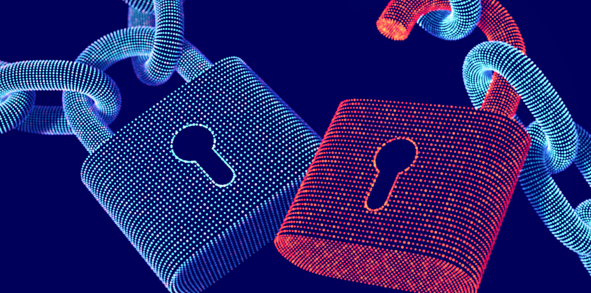

This text will introduce concepts about ethical issues in data science by exploring topics such as privacy (including GDPR), fairness, and accountability. Biases in data will also be touched upon.  
**Key words:** Personal Data, Processing, privacy, ethics, bias, fairness, accountability, GDPR, Lawfulness

## 1. Introduction

The exponential increase in data volume and technological advancement has brought new challenges for both Data Scientists and organizations, particularly regarding legal and ethical considerations. Ethical considerations span across data collection, privacy, and model deployment, bringing challenges in data-driven decision-making and emphasizing the necessity for algorithmic transparency. Although progress has been made, challenges persist and require standardized ethical guidelines.

## 2. Data Ethics & Privacy (GDPR)

### 2.1. GDPR Articles

**4th Article: Definition of Personal Data and Processing**

- **Personal data** is “any information relating to the data subject, which allows for his direct or indirect identification, in particular by reference to an identifier such as a name, an identification number, location data, an online identifier or to one or more factors specific to the physical, physiological, genetic, mental, economic, cultural or social identity of that natural person ” (source: https://www.legislation.gov.uk/eur/2016/679/article/4, paragraph 1).
- **Processing** "means any operation or set of operations which is performed on personal data or sets of personal data, whether or not by automated means, such as collection, recording, organisation, structuring, storage, adaptation or alteration, retrieval, consultation, use, disclosure by transmission, dissemination or otherwise making available, alignment or combination, restriction, erasure or destruction." (source: [https://www.legislation.gov.uk/eur/2016/679/article/4](https://www.legislation.gov.uk/eur/2016/679/article/4,), paragraph 2).

**5th Article: Principles to Process Personal Data**

1. Transparent, lawful, and fair;
2. Limited to its purpose;
3. Minimal, adequate and necessary to the purpose defined (data minimisation);
4. The data should be kept accurate and up-to-date, and not kept longer than needed; and
5. The Integrity and Confidentiality of the data have to be warranted.

**6th Article: Lawfulness of Processing**

Processing shall be lawful only if at least one of the following applies (source: https://www.legislation.gov.uk/eur/2016/679/article/6, paragraph 1):

1. the data subject has given consent for his or her personal data for one or more specific purposes;
2. is necessary for the performance of a contract;
3. is necessary for compliance with a legal obligation;
4. is necessary to protect the vital interests of the data subject or another natural person;
5. is necessary for the performance of a task carried out in the public interest or the exercise of official authority vested in the controller;
6. is necessary for the legitimate interests pursued by the controller or by a third party, except where such interests are overridden by the interests or fundamental rights and freedoms of the data subject which require protection of personal data, in particular where the data subject is a child.

**9th Article: Processing of Special Categories of Personal Data**

Is prohibited to process personal data that “*reveals racial or ethnic origin, political opinions, religious or philosophical beliefs, or trade union membership, and the processing of genetic data, biometric data to uniquely identify a natural person, data concerning health or data concerning a natural person’s sex life or sexual orientation* ”. (source: https://www.legislation.gov.uk/eur/2016/679/article/9). However, there are situations where this prohibition shall not apply (GDPR, Article 9, paragraph 2).

## 3. Fairness

In practice, dealing with fairness faces challenges such as **Bias in Data** (if training data contains biases), **complexity of models** (complex AI models could lead to a difficult interpretation of outcomes), and **context**. Fairness is context-dependent and varies across different applications and user groups.  
Some common metrics allow assess Fairness. However, those metrics depend on the context and goals, and a ongoing monitoring is crucial to detect and rectify bases that could emerge over time.

- **Demographic parity:** Ensuring equal opportunities for different groups
- **Equalized odds:** Balancing true positive and false positive rates among different groups, and
- **Disparate impact:** Identifying and addressing discriminatory effects on specific groups.

### 3.1. Data Bias as a Fairness challenge

Data bias significantly impacts decision-making in Data Science. Data is considered biased when the sample in a study/model does not represent the population of the phenomenon of interest.  
Addressing bias is challenging and lacks a straightforward solution. Merely removing potentitially biased variables may not be feasible, as they could also carry predictive value. This approach could potentially leave us with no variables to work with. Additionally, some variables can serve as "proxies" for sensitive characteristics. For example, if ethnicity or religion are deleted from a model but the names remain, names can inadvertently act as proxies for ethnicity due to their cultural associations.  
Efforts to mitigate bias include adversarial training and fairness-aware machine learning techniques.

## 4. Accountability

Accountability in Data Science projects spans across development, deployment, and ongoing management phases. This responsibility is shared among Data Scientists, organizations, regulators, and policymakers. Data scientists ensure ethical practices, organizations cultivate responsible cultures, and regulators establish legal frameworks. Overall, the collective efforts aim to align ethical standards and fair decision-making expectations.